## Report: act_report

# *WeRateDogs* Twitter Data from 2015 to 2017 – Report

[figure not shown]

[figure not shown]

Every dog on the handle ("doggo" or "pupper" depending on its assumed age) is rated on a scale of 1 to 10. There are times, each dog is given a rating above 10 like "12/10", "15/10" etc.

The handle has been active since 2015 and has gained a massive following on Twitter, Instagram, and Facebook where the posts get thousands of likes and retweets.

I had the chance to analyize some twitter data for my project 2 for the data analyist certificate by ALX and Udacity and will like to share some of my findings!

Though I tried opening one, it was not granted me to open a developer account. So, gathered data for tweets between 2015 and 2017. Made availble by Udacity, Among other data, each tweet had the names of the dogs, its rating, the name of its breed (generated by a neural network image recognition), and its retweet count. These metrics were interesting to me so I sought to answer the follwing questions:

**1. What is the most retweeted tweet?**

**2. What is the most common rating?**

**3. What are the most common breeds found by the neural network?**

**4. How many tweet per month?**

## 1. What is the most retweeted tweet?

The most tweeted *WeRateDogs* tweet (between 2015 and 2017):

[figure not shown]

This very good boy was doggy paddling in the pool then set his back legs down on the bottom of the pool and realized he would just stand and not sink. It must've been a surreal realization for the pup, in addition to the sensation of standing without anyone supporting his arms.

If you haven't yet, take a look the original tweet and video [here](https://twitter.com/dog_rates/status/744234799360020481)! with the tweet id: 744234799360020481 in the master_clean dataset

## 2. What is the most common rating?

Out of the 2000 tweets I examined, surprisingly the most common rating was 12/10, this had over 22% of the whole rating.

It seen that 70% of the tweets examined were rated 10 or higher. What's actually surprising is that 30% of tweets had a rating UNDER 10. I've followed *WeRateDogs* and I've never seen a tweet under 12. If I had more recent data, I would wager that the trend was that the average ratings are getting higher and higher. I believe only the early years, had actual low ratings. I believe 12, 13, 14, and ONLY in rare cases does a dog get 15 nowadays.

## 3. What are the most common breeds found by the neural network?

Though, I analyzied 10 omost common breeds, the neural network did well in correctly identifying the breed of dog, we saw that the percentage of these Top 10 dog breeds is 32% of all tweets.

Here are the top 5 common breeds by number of tweets:

### 5. Pug

[figure not shown]

### 4. Chihuahua

[figure not shown]

### 3. Pembroke (Welsh Corgi)

[figure not shown]

### 2. Labrador Retriever

[figure not shown]

### 1. Golden Retriever

[figure not shown]

### 4. How many tweet per month over the years?

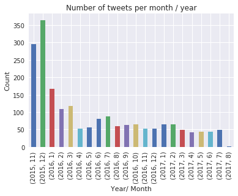

## Conclusion

For the visualization, I tried to identify correlations or longitunal trends but ultimately the scope of data was so limited that the visualizations were inconclusive. I *expected* a high correlation between retweet count and rating, but got an Pearson correlation coefficient r-value only 0.3. Conversely, I tried to show an expected trend in rating verses time yet saw only a slight rise in rating as time went on.

I found that this project had an interesting subject matter, but was limited by the time frame of the tweets. Talking about "most retweeted tweet" between 2015 and 2017 is not a huge feat. Trying to come up with "compelling" and "interesting" insights and visualizations when all I could think up were simple metrics to measure was difficult. This is the first time writing something "blog" style report plus we were not provided examples.

The wrangling process itself was very time-consuming. And I'm somewhat of a perfectionist, so I couldn't let certain issues go unaddressed. But I suppose that was good practice and good experience.